# No Gut Feelings Bank: positioning the balance sheet for the macro cycle

## 11.8 More aggressive?

Being more aggressive does move the numbers more, in both directions, and how much depends on what “more aggressive” means. There are two different dials.

**Bigger moves at the same cost.** Take the optimal downside positioning and scale it by a factor $\alpha$. The benefit if the downside arrives grows in proportion to $\alpha$, but the execution cost grows with its square, so the net gain is $(2\alpha - \alpha^2)$ times the optimum’s: it peaks at the optimum, is gone at twice the optimal size, and turns negative beyond. The loss if the scenario does not arrive keeps growing all the while.

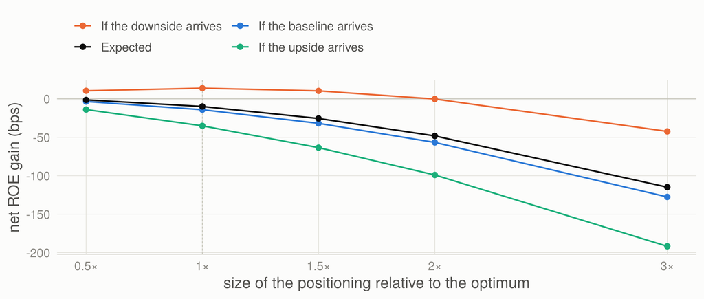

Scaling the optimal downside positioning up and down at the same execution cost: net ROE gain if each scenario arrives, and the probability-weighted expectation.

```r
sz <- szD
sl3 <- rbind(data.frame(alpha = sz$alpha, what = paste("If the", sz$realised, "arrives"), v = sz$gain),
             unique(data.frame(alpha = sz$alpha, what = "Expected", v = sz$exp_gain)))
sl3$what <- factor(sl3$what, levels = c("If the downside arrives", "Expected", "If the baseline arrives", "If the upside arrives"))
ggplot(sl3, aes(alpha, 1e4 * v, colour = what)) +
  geom_hline(yintercept = 0, colour = ink[["axis"]], linewidth = 0.3) +
  geom_vline(xintercept = 1, colour = ink[["axis"]], linewidth = 0.3, linetype = "22") +
  geom_line(linewidth = 0.6) + geom_point(size = 1.8) +
  scale_colour_manual(values = c(`If the downside arrives` = sc_col[["downside"]], Expected = ink[["primary"]],
                                 `If the baseline arrives` = sc_col[["baseline"]], `If the upside arrives` = sc_col[["upside"]])) +
  scale_x_continuous(breaks = unique(sz$alpha), labels = paste0(unique(sz$alpha), "×")) +
  labs(x = "size of the positioning relative to the optimum", y = "net ROE gain (bps)") +
  guides(colour = guide_legend(nrow = 2))
```

**Table view: net gain by size of the downside positioning**

| Size | If baseline arrives (ROE / net income) | If upside arrives (ROE / net income) | If downside arrives (ROE / net income) | Hedge |
| --- | --- | --- | --- | --- |
| 0.5× | -4 bps / -R123 m | -14 bps / -R566 m | +10 bps / +R448 m | -3.6 |
| 1× | -14 bps / -R493 m | -35 bps / -R1,381 m | +14 bps / +R654 m | -7.3 |
| 1.5× | -32 bps / -R1,109 m | -63 bps / -R2,445 m | +10 bps / +R617 m | -10.9 |
| 2× | -57 bps / -R1,972 m | -99 bps / -R3,758 m | +0 bps / +R338 m | -14.6 |
| 3× | -128 bps / -R4,437 m | -192 bps / -R7,133 m | -42 bps / -R945 m | -21.9 |

**A bank that can move faster or more cheaply.** A bank with spare deposit franchise, an underwriting machine ready to scale, or a longer runway can execute the same moves for less. The optimiser then chooses bigger moves: halve the execution costs and the moves, the gain if right and the loss if wrong all double, until a bound binds.

Positioning for the downside when execution is cheaper (and, in the last rows, the bounds are doubled, so the hedge may go from 0% to 100% of NMD): the moves and the net ROE gain if each scenario arrives.

| Execution cost | Bounds | Hedge (pp of NMD) | Unsecured lending (% of assets) | Retail deposits (% of assets) | If downside (bps) | If baseline (bps) | If upside (bps) | Expected (bps) | At a bound |
| --- | --- | --- | --- | --- | --- | --- | --- | --- | --- |
| 1× | as set | -7.3 | -0.46 | +0.49 | +14 | -14 | -35 | -10.0 | nothing |
| 0.5× | as set | -14.6 | -0.91 | +0.97 | +28 | -29 | -71 | -20.4 | nothing |
| 0.25× | as set | -25.0 | -1.82 | +1.95 | +54 | -47 | -123 | -32.1 | hedge |
| 0.1× | as set | -25.0 | -3.00 | +2.00 | +87 | -28 | -111 | -10.0 | cards, personal loans, hedge, commercial property, savings, transactional |
| 0.25× | doubled | -29.1 | -1.82 | +1.95 | +55 | -60 | -146 | -42.6 | nothing |
| 0.1× | doubled | -50.0 | -4.55 | +4.00 | +128 | -88 | -250 | -55.5 | hedge, savings, transactional |

**Table view: the same in net income over three years**

| Execution cost | Bounds | If downside (R m) | If upside (R m) |
| --- | --- | --- | --- |
| 1× | as set | +654 | -1381 |
| 0.5× | as set | +1307 | -2762 |
| 0.25× | as set | +2499 | -4714 |
| 0.1× | as set | +3645 | -4320 |
| 0.25× | doubled | +2614 | -5523 |
| 0.1× | doubled | +5789 | -9109 |

At a quarter of the cost, the hedge hits its policy floor and the downside positioning earns +54 bps (+R2,499 m) if the downside comes, but loses 123 bps (-R4,714 m) if the upside comes. With a tenth of the cost and doubled bounds, which means taking the hedge off entirely, the numbers become +128 bps against -250 bps. The same pattern holds for the upside positioning (+28 bps if right, -115 bps if the downside arrives, at a quarter of the cost).

Three things stop aggressiveness from being free:

- **The loss if wrong grows faster than the gain if right.** The upside and the downside move the same levers in opposite directions, so a bigger downside bet loses more in the upside than it makes in the downside, and with a 30% chance of the downside the probability-weighted value of full-conviction positioning is negative at every size (-10.0 bps at the optimum); the probability-weighted positioning in the previous section is the one that adds value on average.
- **Bounds bind before capital or liquidity do.** Even the most aggressive setting leaves the CET1 trough above 12.2% and the LCR trough above 173%; what stops the moves is the hedge policy and the speed at which a franchise can grow or shrink a book.
- **The answer is only as good as the costs.** The execution costs are assumptions about franchise capacity, and the size of every lending move scales with them. Their direction does not depend on them; their size does.

The optimiser’s linear model stays close to the full engine for moderate settings (within 3.75 bps of ROE down to a quarter of the cost) but drifts at the extremes (up to 17.3 bps when the bounds are doubled and the hedge is pushed towards 0% or 100% of NMD), which is why every number above is the full engine’s, not the linear model’s.

# 12 Market share and market growth: where NGFB should lean in

The positioning chapter moved NGFB’s balance sheet ahead of a scenario. This chapter asks the commercial question underneath it: in which products, and in which phases of the cycle, does NGFB grow more slowly than its market and its peers – and is it worth fixing?

Two numbers place NGFB in each product and regime. The first is how fast the **market** grows in that regime, from the sector’s history (Stage 1’s territory: no bank controls it). The second is NGFB’s **share effect**, how much faster or slower than the market its book grows (Stage 2), compared with the population of large banks it was drawn from. That population gives a *par* (the typical large bank), a spread, and NGFB’s percentile in it; only population hyperparameters are used, never an individual bank’s estimate. NGFB’s structural share drift is left out throughout, so every comparison is about the cycle, not about trend share gains.

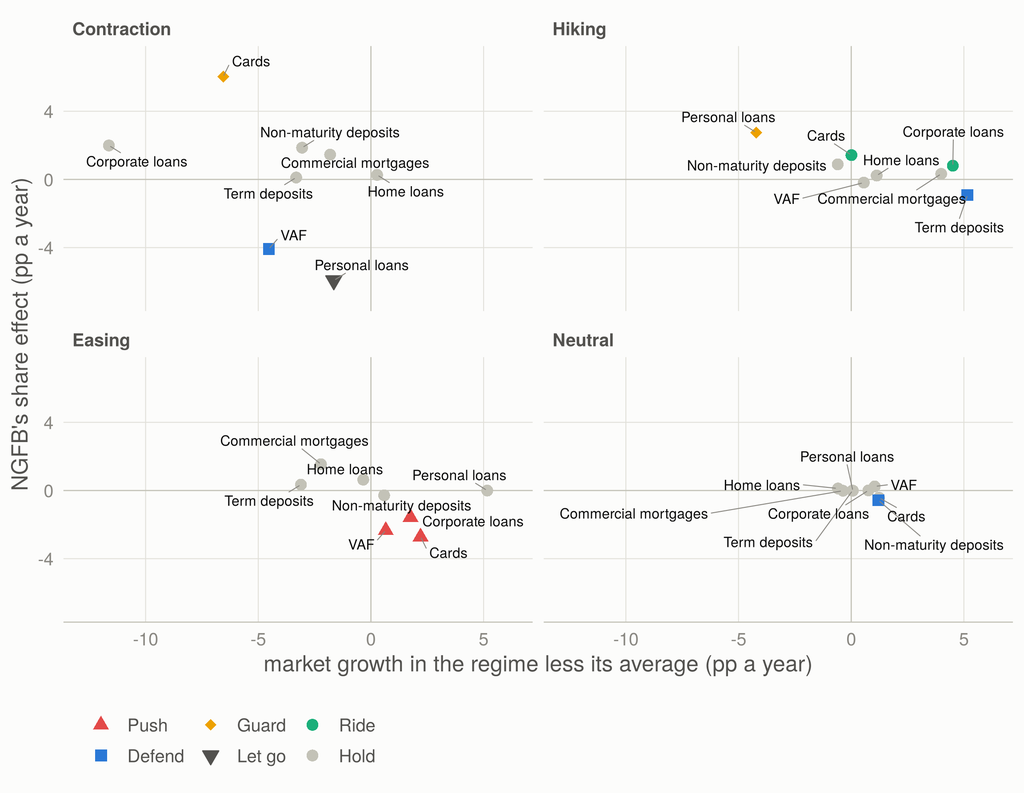

Market growth against NGFB’s share effect, by macro regime. Horizontal axis: how much faster the market grows in the regime than on average; vertical axis: NGFB’s growth relative to the market (percentage points a year). Bottom right: the market grows and NGFB loses share.

```r
mp <- pos
mp$lab <- plab[mp$product]
mp$regime <- factor(rlab[mp$regime], levels = rlab)
act_lv <- c("Push", "Defend", "Guard", "Let go", "Ride", "Hold")
act_col <- c(Push = "#e34948", Defend = "#2a78d6", Guard = "#eda100", `Let go` = "#52514e",
             Ride = "#1baf7a", Hold = "#c3c2b7")
act_shp <- c(Push = 17, Defend = 15, Guard = 18, `Let go` = 25, Ride = 16, Hold = 16)
mp$action <- factor(mp$action, levels = act_lv)
ggplot(mp, aes(market_dev, ngfb_effect)) +
  geom_hline(yintercept = 0, colour = ink[["axis"]], linewidth = 0.3) +
  geom_vline(xintercept = 0, colour = ink[["axis"]], linewidth = 0.3) +
  geom_point(aes(colour = action, fill = action, shape = action), size = 2.8) +
  ggrepel::geom_text_repel(aes(label = lab), size = 2.8, colour = ink[["primary"]], min.segment.length = 0.3,
                           segment.colour = ink[["muted"]], segment.size = 0.25, max.overlaps = Inf,
                           box.padding = 0.35, seed = 1) +
  facet_wrap(~ regime, ncol = 2) +
  scale_x_continuous(expand = expansion(mult = 0.12)) +
  scale_y_continuous(expand = expansion(mult = 0.15)) +
  scale_colour_manual(values = act_col, breaks = act_lv, name = NULL, drop = FALSE) +
  scale_fill_manual(values = act_col, breaks = act_lv, name = NULL, drop = FALSE) +
  scale_shape_manual(values = act_shp, breaks = act_lv, name = NULL, drop = FALSE) +
  labs(x = "market growth in the regime less its average (pp a year)",
       y = "NGFB's share effect (pp a year)") +
  theme(legend.position = "bottom")
```

**Table view: every product and regime**

| Product | Regime | Market growth (% a year) | NGFB share effect (pp) | Par (pp) | Percentile | Action |
| --- | --- | --- | --- | --- | --- | --- |
| Term deposits | Contraction | 2.5 | +0.11 | -0.47 | 56% | Hold |
| Term deposits | Easing | 2.7 | +0.34 | +1.62 | 38% | Hold |
| Term deposits | Hiking | 11.0 | -0.92 | +0.57 | 29% | Defend |
| Term deposits | Neutral | 5.9 | -0.01 | 0.00 | 34% | Hold |
| Cards | Contraction | 0.3 | +6.03 | +1.30 | 75% | Guard |
| Cards | Easing | 9.1 | -2.71 | -2.18 | 46% | Push |
| Cards | Hiking | 6.9 | +1.43 | +1.20 | 58% | Ride |
| Cards | Neutral | 8.1 | -0.42 | -0.50 | 58% | Hold |
| Corporate loans | Contraction | -4.0 | +1.99 | +0.46 | 62% | Hold |
| Corporate loans | Easing | 9.4 | -1.57 | -0.34 | 34% | Push |
| Corporate loans | Hiking | 12.2 | +0.81 | -0.27 | 72% | Ride |
| Corporate loans | Neutral | 8.4 | +0.01 | -0.05 | 67% | Hold |
| Commercial mortgages | Contraction | 4.9 | +1.46 | +0.26 | 74% | Hold |
| Commercial mortgages | Easing | 4.5 | +1.54 | +1.48 | 52% | Hold |
| Commercial mortgages | Hiking | 10.7 | +0.33 | +0.28 | 51% | Hold |
| Commercial mortgages | Neutral | 6.4 | -0.01 | +0.02 | 33% | Hold |
| Home loans | Contraction | 4.1 | +0.26 | +0.70 | 21% | Hold |
| Home loans | Easing | 3.5 | +0.63 | +0.34 | 66% | Hold |
| Home loans | Hiking | 4.9 | +0.23 | +0.08 | 58% | Hold |
| Home loans | Neutral | 3.2 | +0.12 | +0.08 | 55% | Hold |
| Non-maturity deposits | Contraction | 4.1 | +1.86 | +1.05 | 70% | Hold |
| Non-maturity deposits | Easing | 7.7 | -0.29 | -0.13 | 45% | Hold |
| Non-maturity deposits | Hiking | 6.5 | +0.89 | +0.33 | 69% | Hold |
| Non-maturity deposits | Neutral | 8.3 | -0.57 | -0.23 | 19% | Defend |
| Personal loans | Contraction | 6.7 | -5.93 | +1.34 | 26% | Let go |
| Personal loans | Easing | 13.5 | 0.00 | -1.16 | 66% | Hold |
| Personal loans | Hiking | 4.2 | +2.75 | +4.47 | 24% | Guard |
| Personal loans | Neutral | 8.4 | -0.01 | -0.03 | 77% | Hold |
| VAF | Contraction | 1.2 | -4.08 | -2.33 | 18% | Defend |
| VAF | Easing | 6.4 | -2.34 | -1.23 | 40% | Push |
| VAF | Hiking | 6.3 | -0.19 | +0.24 | 41% | Hold |
| VAF | Neutral | 6.8 | +0.24 | +0.12 | 69% | Hold |

The rules that turn a cell into an action are economic, not statistical. A share **loss** in a regime where the market grows at or above its average is under-participation: the cheapest growth NGFB forgoes, so **push**. A share **gain** in unsecured lending while the market weakens is a warning: NGFB may be booking the business others decline, so **guard**. Ceding unsecured share in a contraction is the risk appetite working: **let go**. Losing share in a weak market for a secured or funding product means competitors are taking good-quality business: **defend**. Gains in a growing market: **ride**, with capacity and pricing discipline.

The share playbook: every product and regime where NGFB should act. Who gains: the peer groups that take the share NGFB loses in that regime (proportional convention; history with NGFB embedded).

| Action | Product | Regime | Market growth (% a year) | NGFB vs market (pp a year) | Typical large bank (pp) | Percentile | Who gains NGFB’s loss | Why |
| --- | --- | --- | --- | --- | --- | --- | --- | --- |
| Push | Cards | Easing | 9.1 | -2.7 | -2.2 | 46% | Challengers (100%) | Losing share when the market grows fastest: the cheapest growth NGFB forgoes. |
| Push | Corporate loans | Easing | 9.4 | -1.6 | -0.3 | 34% | Other (50%), Specialists (34%), Challengers (16%) | Losing share when the market grows fastest: the cheapest growth NGFB forgoes. |
| Push | VAF | Easing | 6.4 | -2.3 | -1.2 | 40% | Challengers (50%), Big Four (50%) | Losing share when the market grows fastest: the cheapest growth NGFB forgoes. |
| Defend | Term deposits | Hiking | 11.0 | -0.9 | +0.6 | 29% | Big Four (100%) | Losing deposit share in a growing deposit market: funding NGFB will later buy wholesale. |
| Defend | Non-maturity deposits | Neutral | 8.3 | -0.6 | -0.2 | 19% | Challengers (98%) | Losing deposit share in a growing deposit market: funding NGFB will later buy wholesale. |
| Defend | VAF | Contraction | 1.2 | -4.1 | -2.3 | 18% | Specialists (97%) | Losing share in a weak market: competitors are taking good-quality business. |
| Guard | Cards | Contraction | 0.3 | +6.0 | +1.3 | 75% | – | Gaining unsecured share while the market weakens: check it is not the business others decline. |
| Guard | Personal loans | Hiking | 4.2 | +2.8 | +4.5 | 24% | – | Gaining unsecured share while the market weakens: check it is not the business others decline. |
| Let go | Personal loans | Contraction | 6.7 | -5.9 | +1.3 | 26% | Challengers (76%), Specialists (23%) | Ceding unsecured share in a contraction is risk appetite working, not a weakness. |
| Ride | Cards | Hiking | 6.9 | +1.4 | +1.2 | 58% | – | Gaining share in a growing market: keep capacity and pricing discipline. |
| Ride | Corporate loans | Hiking | 12.2 | +0.8 | -0.3 | 72% | – | Gaining share in a growing market: keep capacity and pricing discipline. |

**The gap is in easing cycles.** When rates fall, the card market grows 9.1% a year against an average of 6.9%, yet NGFB’s card book grows 271 bps a year more slowly than the market (46% percentile). It is not alone: the typical large bank loses 218 bps a year of card growth in an easing cycle too, and the Challengers take 100% of what NGFB loses. Corporate loans (-1.6 pp a year, 34% percentile) and vehicle and asset finance (-2.3 pp, 40% percentile) follow the same pattern, in markets growing 9.4% and 6.4% a year. In hiking cycles the picture reverses: NGFB gains card share (+1.4 pp a year), so the pattern a bank might expect – losing cards when rates are high – is not NGFB’s problem; losing them when rates fall is.

## 12.1 Is it worth pushing?

Share is worth buying only if the extra business earns more than it costs at the margin. The scenario engine is the wrong tool for that question: it grows NGFB’s treasury and other assets along with its loan book, which is right for a scenario but not for a single-product decision. So each product’s marginal economics are built up directly, per rand of balance: the yield, less the funds-transfer price (the marginal wholesale rate), less the cost of the HQLA buffer that wholesale funding needs for its 30-day runoff, less expected losses at the product’s loss rate, after tax, less a charge for the capital it consumes at a 12.5% CET1 target and a 14.5% cost of equity. Deposits earn the funding they displace. The BA returns carry no costs by product, so the result is a contribution *before* operating costs: the most it could cost to originate and service the business before it destroys value (the headroom).

Marginal economics in the baseline, percent a year of balance (three-year averages). Headroom: pre-tax contribution after funding, liquidity, expected losses, tax and the capital charge, before operating costs. ‘Own deposits’: the push brings matching deposits, funded at NGFB’s average cost of funds.

| Product | Rate (%) | FTP (%) | Liquidity buffer | Expected loss | Capital charge | Headroom, wholesale funding | Headroom, own deposits |
| --- | --- | --- | --- | --- | --- | --- | --- |
| Home loans | 9.37 | 7.90 | 0.66 | 0.27 | 0.27 | +0.20 | +2.57 |
| Commercial mortgages | 9.17 | 7.90 | 0.66 | 0.38 | 0.56 | -0.48 | +1.82 |
| VAF | 10.68 | 7.90 | 0.66 | 1.29 | 0.61 | +0.06 | +2.34 |
| Cards | 15.28 | 7.90 | 0.66 | 4.30 | 0.56 | +1.72 | +4.02 |
| Personal loans | 18.21 | 7.90 | 0.66 | 6.98 | 0.61 | +1.89 | +4.18 |
| Corporate loans | 10.60 | 7.90 | 0.66 | 0.57 | 0.44 | +0.91 | +3.24 |
| Non-maturity deposits | 5.26 | 7.90 | 0.72 | 0.00 | 0.00 | +1.92 | – |
| Term deposits | 7.15 | 7.90 | 0.19 | 0.00 | 0.00 | +0.56 | – |

Cards clear the bar comfortably even on wholesale funding (+1.7 pp of headroom). Corporate lending clears it only narrowly (+0.9 pp) and vehicle and asset finance barely at all (+0.06 pp); with matching deposits both have 3.2 and 2.3 pp to spare. The commercial lesson is the same for every secured product: at NGFB’s margins, lending growth pays when it brings its own funding.

What closing each gap is worth: contribution over three years, before operating costs, if NGFB’s share effect in that regime moved to the typical large bank’s (par) or to a top-quintile bank’s (frontier). Only scenarios that contain the regime are shown.

| Strategy | Scenario | Extra book at the frontier (R bn) | To par, wholesale (R m) | To par, own deposits (R m) | To the frontier, wholesale (R m) | To the frontier, own deposits (R m) |
| --- | --- | --- | --- | --- | --- | --- |
| Term deposits, hiking | Baseline | 7.3 | +26 | – | +82 | – |
| Term deposits, hiking | Downside | 11.0 | +26 | – | +83 | – |
| Cards, easing | Baseline | 6.4 | +14 | +33 | +105 | +241 |
| Cards, easing | Upside | 8.7 | +30 | +57 | +222 | +418 |
| Corporate loans, easing | Baseline | 18.4 | +56 | +191 | +163 | +558 |
| Corporate loans, easing | Upside | 25.6 | +100 | +295 | +294 | +867 |
| VAF, contraction | Downside | 3.8 | -4 | +40 | -8 | +84 |
| VAF, easing | Baseline | 6.1 | +2 | +33 | +9 | +139 |
| VAF, easing | Upside | 8.5 | +9 | +54 | +37 | +227 |

Moving every push and defend cell to par adds +R98 m to +R257 m of contribution over three years in the baseline (+4 bps to +9 bps of ROE before operating costs), and +R139 m to +R405 m in the upside, whose eight easing quarters are where the gaps sit. These are modest because NGFB is a typical large bank by construction: the prize is in moving to the frontier, where corporate lending alone is worth +R867 m in the upside if the book brings its deposits.

**Guard: cards in a contraction.** In contractions NGFB *gains* card share (+6.0 pp a year, 75% percentile) while the card market all but stops (0.3% a year). At the average card loss rate the extra book still pays – giving it up would cost R59 m over the downside – but its headroom is only 0.8 pp: if the accounts won in a downturn lose more than that above the average card loss rate, the share gain destroys value. Adverse selection in a contraction (the customers other banks are declining) makes that likely, so the action is to tighten underwriting on new card business when GDP turns, not to celebrate the share. Personal loans in hiking cycles carry the same flag; in contractions NGFB cedes personal-loan share (26% percentile, mostly to the Challengers), which is the risk appetite working.

**Defend: term deposits when rates rise.** In hiking cycles the term-deposit market grows 11.0% a year and NGFB’s share falls (-0.9 pp a year against a par of +0.6). Each rand of term deposits displaces wholesale funding with 0.6 pp of headroom, so price-matching term deposits in a hiking cycle pays as long as gathering them costs less than that.

**Caveats**

The positioning comes from NGFB’s drawn share parameters, which are a typical large bank’s behaviour plus a random deviation (seed 20260622); a real bank would use its own estimates. Share effects are averages over the regime’s history, with wide uncertainty for unsecured products. Contributions exclude operating costs and fee income, both of which the returns do not report by product, and the frontier is a statistical construct (the 80th percentile of the population’s predictive distribution), not a named competitor.

# 13 Macro-adjusted performance: could NGFB have done better?

A product’s growth is the market’s growth plus the bank’s share effect. The first part is the macro environment: Stage 1 says what the industry does in a scenario, and no bank controls it. The second is what management controls, and Stage 2 says what a typical large bank achieves in the same regimes. So performance can be judged against two macro-adjusted benchmarks: **par**, the share effect of the typical large bank, and the **frontier**, that of a top-quintile large bank (the 80th percentile of the population’s posterior predictive). NGFB’s percentile says how much better it could have done; the gap to the frontier says by how much. Over a scenario the benchmarks are summed quarter by quarter along its sequence of regimes and market growth, exactly as NGFB’s own share effect is.

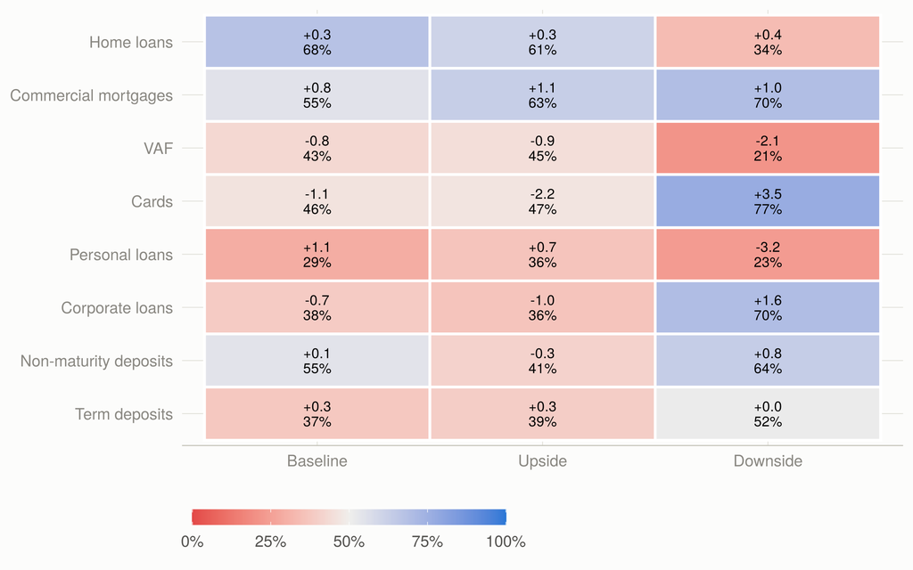

NGFB’s share performance by scenario against the large-bank population: percentile of NGFB’s share effect (blue above par, red below), labelled with the effect in percentage points a year.

```r
hz <- sc
hz$lab <- plab[hz$product]; hz$lab <- factor(hz$lab, levels = rev(plab))
hz$scenario <- factor(sc_short[hz$scenario], levels = sc_short[scen])
ggplot(hz, aes(scenario, lab, fill = percentile)) +
  geom_tile(colour = "white", linewidth = 0.8) +
  geom_text(aes(label = sprintf("%+.1f\n%s", round(share_effect, 1) + 0, pct(percentile, 0))), size = 3.1, lineheight = 0.9) +
  scale_fill_gradient2(low = div_lo, mid = div_mid, high = div_hi, midpoint = 0.5, limits = c(0, 1),
                       breaks = c(0, 0.25, 0.5, 0.75, 1), labels = scales::percent_format(1),
                       name = "NGFB's percentile among large banks") +
  guides(fill = guide_colourbar(barwidth = grid::unit(7, "cm"), barheight = grid::unit(0.35, "cm"),
                                title.position = "top")) +
  labs(x = NULL, y = NULL) +
  theme(panel.grid = element_blank(), legend.position = "bottom")
```

**Table view: scorecards**

| Scenario | Product | Market growth (% a year) | NGFB growth | Share effect (pp) | Par (pp) | Frontier (pp) | Percentile | Verdict |
| --- | --- | --- | --- | --- | --- | --- | --- | --- |
| Baseline | Home loans | 3.9 | 4.2 | +0.35 | +0.18 | +0.48 | 68% | Above par |
| Baseline | Commercial mortgages | 6.7 | 7.6 | +0.84 | +0.76 | +1.29 | 55% | Above par |
| Baseline | VAF | 7.9 | 7.1 | -0.80 | -0.37 | +1.54 | 43% | Below par |
| Baseline | Cards | 7.8 | 6.7 | -1.06 | -0.82 | +1.27 | 46% | Below par |
| Baseline | Personal loans | 5.9 | 7.0 | +1.06 | +1.84 | +3.01 | 29% | Well below par |
| Baseline | Corporate loans | 9.0 | 8.4 | -0.65 | -0.20 | +1.10 | 38% | Below par |
| Baseline | Non-maturity deposits | 7.1 | 7.2 | +0.09 | +0.02 | +0.51 | 55% | Above par |
| Baseline | Term deposits | 3.8 | 4.0 | +0.25 | +0.97 | +2.85 | 37% | Below par |
| Upside | Home loans | 4.2 | 4.5 | +0.29 | +0.14 | +0.58 | 61% | Above par |
| Upside | Commercial mortgages | 8.0 | 9.1 | +1.13 | +0.85 | +1.55 | 63% | Above par |
| Upside | VAF | 9.1 | 8.2 | -0.90 | -0.49 | +2.06 | 45% | Below par |
| Upside | Cards | 9.4 | 7.2 | -2.17 | -1.88 | +0.96 | 47% | Below par |
| Upside | Personal loans | 6.4 | 7.2 | +0.75 | +1.31 | +2.64 | 36% | Below par |
| Upside | Corporate loans | 10.4 | 9.3 | -1.04 | -0.32 | +1.41 | 36% | Below par |
| Upside | Non-maturity deposits | 7.8 | 7.5 | -0.32 | -0.14 | +0.50 | 41% | Below par |
| Upside | Term deposits | 3.3 | 3.6 | +0.30 | +1.10 | +3.56 | 39% | Below par |
| Downside | Home loans | 3.3 | 3.7 | +0.43 | +0.61 | +0.98 | 34% | Below par |
| Downside | Commercial mortgages | 4.9 | 5.9 | +0.99 | +0.33 | +1.42 | 70% | Above par |
| Downside | VAF | 5.9 | 3.8 | -2.07 | -1.15 | -0.18 | 21% | Well below par |
| Downside | Cards | 5.1 | 8.6 | +3.47 | +0.09 | +3.93 | 77% | Near the frontier |
| Downside | Personal loans | 5.4 | 2.3 | -3.15 | +2.31 | +8.63 | 23% | Well below par |
| Downside | Corporate loans | 7.0 | 8.5 | +1.57 | -0.12 | +2.61 | 70% | Above par |
| Downside | Non-maturity deposits | 6.2 | 7.1 | +0.84 | +0.54 | +1.26 | 64% | Above par |
| Downside | Term deposits | 4.3 | 4.2 | -0.04 | -0.14 | +2.03 | 52% | Above par |

**In the downside**, most of the slowdown in NGFB’s books is the market’s. Home-loan growth falls 47 bps a year against the baseline, all of it market (-0.55 pp) – but even so NGFB is below par in home loans (34% percentile), because a typical large bank *gains* mortgage share in a contraction as lenders retreat to secured credit, and NGFB gains less: in a downturn NGFB should lean into home loans, with deposit funding (the wholesale headroom is thin). Cards are near the frontier (77% percentile, 0.5 pp a year short of it), with corporate loans and commercial mortgages close behind (70%): on share, NGFB could hardly have done better – and in cards that is precisely the guard case of the previous chapter. Vehicle and asset finance and personal loans are well below par.

**In the upside**, the growth is in cards, corporate lending and vehicle and asset finance, and NGFB is below par in all three: in cards the market adds +1.6 pp a year to growth against the baseline and NGFB’s share takes -1.1 pp back. The upside’s message for management is to protect share where the growth is, not to bank the tide.

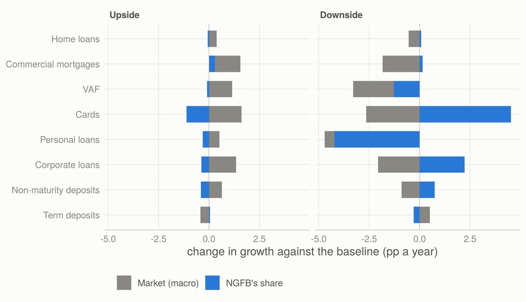

Change in NGFB’s annual growth against the baseline, split into the market (macro: no bank controls it) and NGFB’s share effect (management).

```r
ab <- rbind(data.frame(scenario = vb$scenario, product = vb$product, part = "Market (macro)", v = vb$d_market),
            data.frame(scenario = vb$scenario, product = vb$product, part = "NGFB's share", v = vb$d_share))
ab$lab <- factor(plab[ab$product], levels = rev(plab))
ab$scenario <- factor(sc_short[ab$scenario], levels = sc_short[c("upside", "downside")])
ggplot(ab, aes(v, lab, fill = part)) +
  geom_vline(xintercept = 0, colour = ink[["axis"]], linewidth = 0.3) +
  geom_col(width = 0.65) +
  facet_wrap(~ scenario) +
  scale_fill_manual(values = c(`Market (macro)` = ink[["muted"]], `NGFB's share` = ent_col[["NGFB"]]), name = NULL) +
  labs(x = "change in growth against the baseline (pp a year)", y = NULL) +
  theme(legend.position = "bottom")
```

**Table view: attribution against the baseline**

| Scenario | Product | Change in growth (pp) | Market (pp) | Share (pp) |
| --- | --- | --- | --- | --- |
| Upside | Term deposits | -0.38 | -0.43 | +0.05 |
| Upside | Cards | +0.49 | +1.61 | -1.11 |
| Upside | Corporate loans | +0.96 | +1.34 | -0.38 |
| Upside | Commercial mortgages | +1.55 | +1.27 | +0.29 |
| Upside | Home loans | +0.32 | +0.37 | -0.06 |
| Upside | Non-maturity deposits | +0.23 | +0.64 | -0.40 |
| Upside | Personal loans | +0.20 | +0.51 | -0.31 |
| Upside | VAF | +1.04 | +1.14 | -0.10 |
| Downside | Term deposits | +0.21 | +0.51 | -0.29 |
| Downside | Cards | +1.88 | -2.65 | +4.53 |
| Downside | Corporate loans | +0.17 | -2.06 | +2.23 |
| Downside | Commercial mortgages | -1.68 | -1.83 | +0.15 |
| Downside | Home loans | -0.47 | -0.55 | +0.08 |
| Downside | Non-maturity deposits | -0.14 | -0.89 | +0.75 |
| Downside | Personal loans | -4.70 | -0.48 | -4.22 |
| Downside | VAF | -3.29 | -2.02 | -1.27 |

## 13.1 Using it to set and judge targets

The same split turns into a macro-adjusted target. For product $p$ in quarter $t$:

$$\text{target}_{p,t} = \underbrace{g^{\text{market}}_{p,t}}_{\text{realised, from the returns}} + \underbrace{\text{par}_{p}(\text{regime}_t)}_{\text{Stage 2}} + \text{ambition}_p,$$

and performance is actual growth less the target. The market term is measured after the fact, so a bank is neither punished for a recession nor rewarded for a boom; the par term adjusts for what a typical large bank does in that phase of the cycle; the ambition is management’s choice (for NGFB, the gap to the frontier). Set in advance, the scorecards above become scenario-contingent targets: in a downside, a home-loan share gain of at least par; in an upside, no loss of card or corporate share.

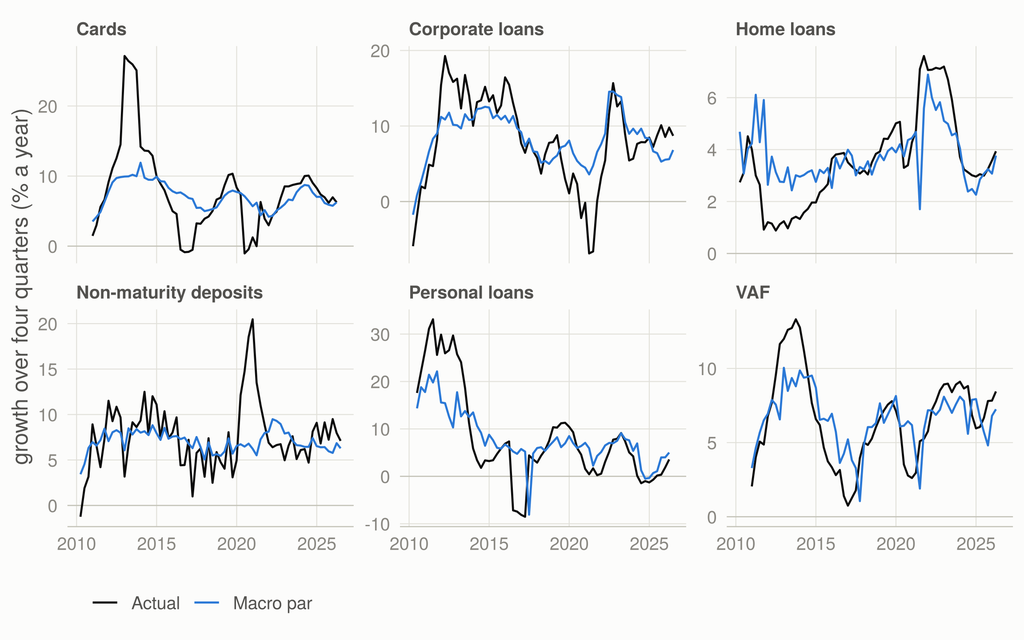

The industry against macro par: actual growth over four quarters against what each Stage 1 model implied from the realised macro path (simulated four quarters ahead from each quarter), selected products.

```r
hh <- hpar[hpar$target %in% c("g_mortgages_res", "g_vaf", "g_cards", "g_personal_other", "g_corp_all", "g_nmd"), ]
hh$lab <- plab[sub("^g_", "", hh$target)]
hl <- rbind(data.frame(date = hh$date, lab = hh$lab, what = "Actual", v = hh$actual),
            data.frame(date = hh$date, lab = hh$lab, what = "Macro par", v = hh$implied))
ggplot(hl, aes(date, v, colour = what)) +
  geom_hline(yintercept = 0, colour = ink[["axis"]], linewidth = 0.3) +
  geom_line(linewidth = 0.55) +
  facet_wrap(~ lab, ncol = 3, scales = "free_y") +
  scale_colour_manual(values = c(Actual = ink[["primary"]], `Macro par` = ent_col[["NGFB"]]), name = NULL) +
  labs(x = NULL, y = "growth over four quarters (% a year)") +
  theme(legend.position = "bottom")
```

Over the last three years the industry beat macro par in cards (+0.9 pp a year), vehicle and asset finance and deposits, and fell short in personal loans by 2.2 pp a year: lenders tightened unsecured credit by more than growth, rates and unemployment alone explain. The same comparison, run for a bank’s own books, is the macro-adjusted scorecard: it separates the tide from the swimming.

# 14 Validation

## 14.1 Back-test: would the industry models have tracked the industry?

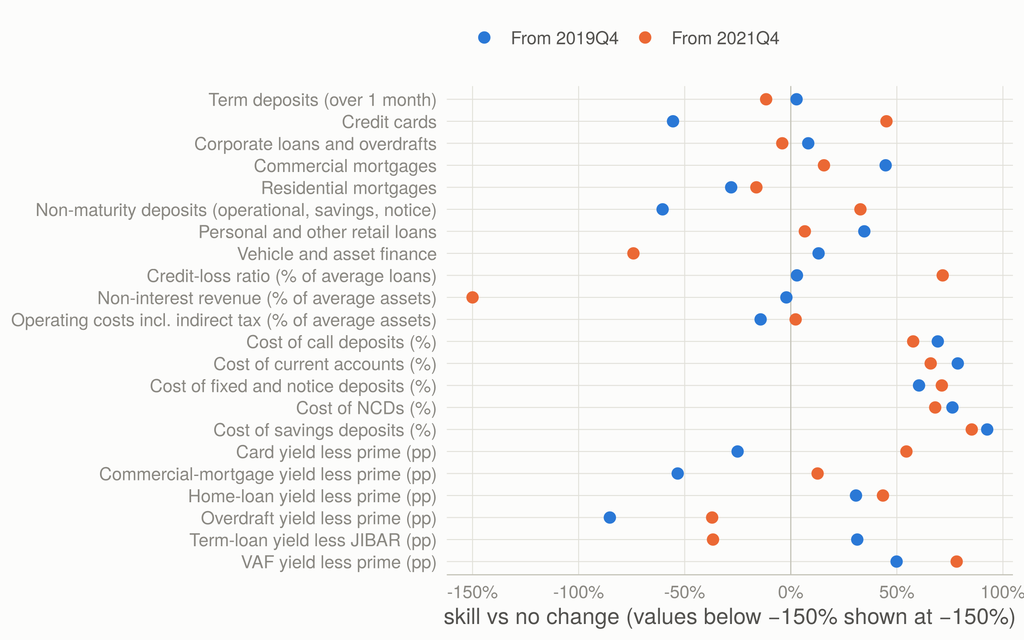

Skill against a no-change forecast over eight quarters, re-estimating every Stage 1 model on data to the origin and projecting it along the realised macro path. Ratio targets with the intercept correction.

```r
ba <- BT$accuracy
ba$label <- S1$summary$label[match(ba$target, S1$summary$target)]
ba$origin_lab <- paste("From", qlab(ba$origin))
ba$sk <- pmax(ba$skill_used, -1.5)
ba$label <- factor(ba$label, levels = rev(S1$summary$label[order(match(S1$summary$family, c("volume", "credit", "pnl", "pricing")), S1$summary$target)]))
ggplot(ba, aes(sk, label, colour = origin_lab)) +
  geom_vline(xintercept = 0, colour = ink[["axis"]], linewidth = 0.3) +
  geom_point(size = 2.6) +
  scale_colour_manual(values = unname(pal$categorical[1:2])) +
  scale_x_continuous(labels = scales::percent_format(1)) +
  labs(x = "skill vs no change (values below −150% shown at −150%)", y = NULL)
```

**Table view**

| Target | Origin | RMSE model | RMSE model + IC | RMSE no change | Skill | Skill + IC |
| --- | --- | --- | --- | --- | --- | --- |
| Cost of call deposits (%) | 2019Q4 | 0.42 | 0.48 | 1.56 | 73% | 69% |
| Cost of call deposits (%) | 2021Q4 | 1.26 | 1.25 | 2.95 | 57% | 58% |
| Cost of current accounts (%) | 2019Q4 | 0.43 | 0.34 | 1.62 | 73% | 79% |
| Cost of current accounts (%) | 2021Q4 | 0.54 | 0.50 | 1.48 | 63% | 66% |
| Cost of fixed and notice deposits (%) | 2019Q4 | 1.03 | 0.93 | 2.36 | 56% | 60% |
| Cost of fixed and notice deposits (%) | 2021Q4 | 0.73 | 0.78 | 2.69 | 73% | 71% |
| Cost of NCDs (%) | 2019Q4 | 0.84 | 0.65 | 2.75 | 69% | 76% |
| Cost of NCDs (%) | 2021Q4 | 0.78 | 0.79 | 2.48 | 69% | 68% |
| Cost of savings deposits (%) | 2019Q4 | 0.14 | 0.12 | 1.64 | 92% | 93% |
| Cost of savings deposits (%) | 2021Q4 | 0.29 | 0.32 | 2.19 | 87% | 85% |
| Credit-loss ratio (% of average loans) | 2019Q4 | 0.78 | 0.78 | 0.81 | 3% | 3% |
| Credit-loss ratio (% of average loans) | 2021Q4 | 0.19 | 0.13 | 0.46 | 58% | 72% |
| Term deposits (over 1 month) | 2019Q4 | 17.07 | 17.07 | 17.55 | 3% | 3% |
| Term deposits (over 1 month) | 2021Q4 | 13.29 | 13.29 | 11.91 | -12% | -12% |
| Credit cards | 2019Q4 | 16.03 | 16.03 | 10.31 | -56% | -56% |
| Credit cards | 2021Q4 | 4.89 | 4.89 | 8.90 | 45% | 45% |
| Corporate loans and overdrafts | 2019Q4 | 14.46 | 14.46 | 15.75 | 8% | 8% |
| Corporate loans and overdrafts | 2021Q4 | 9.80 | 9.80 | 9.43 | -4% | -4% |
| Commercial mortgages | 2019Q4 | 4.05 | 4.05 | 7.33 | 45% | 45% |
| Commercial mortgages | 2021Q4 | 4.81 | 4.81 | 5.70 | 16% | 16% |
| Residential mortgages | 2019Q4 | 4.47 | 4.47 | 3.49 | -28% | -28% |
| Residential mortgages | 2021Q4 | 2.68 | 2.68 | 2.31 | -16% | -16% |
| Non-maturity deposits (operational, savings, notice) | 2019Q4 | 14.01 | 14.01 | 8.73 | -60% | -60% |
| Non-maturity deposits (operational, savings, notice) | 2021Q4 | 5.81 | 5.81 | 8.65 | 33% | 33% |
| Personal and other retail loans | 2019Q4 | 8.40 | 8.40 | 12.86 | 35% | 35% |
| Personal and other retail loans | 2021Q4 | 6.51 | 6.51 | 6.98 | 7% | 7% |
| Vehicle and asset finance | 2019Q4 | 4.07 | 4.07 | 4.69 | 13% | 13% |
| Vehicle and asset finance | 2021Q4 | 3.57 | 3.57 | 2.05 | -74% | -74% |
| Non-interest revenue (% of average assets) | 2019Q4 | 0.46 | 0.37 | 0.36 | -28% | -2% |
| Non-interest revenue (% of average assets) | 2021Q4 | 0.44 | 0.33 | 0.12 | -267% | -177% |
| Operating costs incl. indirect tax (% of average assets) | 2019Q4 | 0.38 | 0.36 | 0.32 | -20% | -14% |
| Operating costs incl. indirect tax (% of average assets) | 2021Q4 | 0.11 | 0.09 | 0.09 | -13% | 2% |
| Card yield less prime (pp) | 2019Q4 | 0.57 | 0.27 | 0.21 | -166% | -25% |
| Card yield less prime (pp) | 2021Q4 | 0.35 | 0.30 | 0.65 | 46% | 55% |
| Commercial-mortgage yield less prime (pp) | 2019Q4 | 0.44 | 0.59 | 0.39 | -13% | -53% |
| Commercial-mortgage yield less prime (pp) | 2021Q4 | 0.43 | 0.49 | 0.56 | 23% | 13% |
| Home-loan yield less prime (pp) | 2019Q4 | 0.26 | 0.23 | 0.33 | 20% | 31% |
| Home-loan yield less prime (pp) | 2021Q4 | 0.22 | 0.21 | 0.37 | 41% | 43% |
| Overdraft yield less prime (pp) | 2019Q4 | 1.81 | 1.74 | 0.94 | -93% | -85% |
| Overdraft yield less prime (pp) | 2021Q4 | 1.03 | 1.04 | 0.76 | -35% | -37% |
| Term-loan yield less JIBAR (pp) | 2019Q4 | 1.10 | 1.14 | 1.66 | 34% | 31% |
| Term-loan yield less JIBAR (pp) | 2021Q4 | 1.67 | 1.66 | 1.21 | -38% | -37% |
| VAF yield less prime (pp) | 2019Q4 | 0.20 | 0.20 | 0.40 | 51% | 50% |
| VAF yield less prime (pp) | 2021Q4 | 0.23 | 0.22 | 1.03 | 77% | 78% |

The back-test asks the question a scenario tool must answer: *if the macro path had been known*, would the models have tracked the sector? From the eve of COVID (2019Q4) and the eve of the 2022–23 hiking cycle (2021Q4), every Stage 1 model is re-estimated on data to the origin only and projected eight quarters along the realised macro path. The model beats no change in 29 of 44 target-origins.

Back-test skill by family (two origins, eight quarters).

| Family | Median skill, no correction | Median skill, intercept correction |
| --- | --- | --- |
| Pricing (spreads, deposit costs) | 54% | 56% |
| Credit (credit-loss ratio) | 31% | 37% |
| Fees and costs (over assets) | -24% | -8% |
| Volumes (growth) | 5% | not applied |

The pricing and credit models carry real information; the volume models carry a little; the fee and cost ratios are better forecast by “no change” than by a model that mean-reverts to a 2008–2025 average the industry has since left (non-interest revenue over assets has drifted down). The intercept correction narrows that gap for non-interest revenue and improves the median in every ratio family, so it is used for all ratio targets; it is not applied to volume growth, where recent residuals are mostly noise.

## 14.2 Does the engine’s first year look like the industry’s last year?

Sector P&L: BA120 2024Q3–2025Q2 against the engine’s baseline 2026Q3–2027Q2.

| Item | Last four BA120 quarters, R bn | Engine, first projected year, R bn | Change |
| --- | --- | --- | --- |
| Net interest income | 249 | 262 | +5% |
| Non-interest revenue | 170 | 214 | +26% |
| Operating costs incl. indirect tax | 245 | 290 | +18% |
| Credit impairments | 52 | 58 | +12% |
| Profit before tax | 121 | 128 | +6% |
| Average total assets | 8,252 | 9,664 | +17% |

The engine’s first projected year starts four quarters after the last BA120 quarter, on a balance sheet +17% larger (BA900 grew +9% between the two dates). Revenue and costs scale with it, and the engine’s sector ROE in the first year, 14.0%, compares with 15.6% on BA100’s ordinary equity in the last four quarters. The residual differences are the scenario’s rate path and the intercept-corrected ratios.

## 14.3 Other checks

- **Engine arithmetic.** The balance sheet balances in every quarter of every run (relative error below 10⁻⁹); channel attributions reproduce the full-engine runs exactly in ROE and in net income; the bridges add up to the positioned ROE and net income (all guarded in the scripts).
- **Optimiser.** The linear prediction of the quadratic programme agrees with the full engine to 0.24 bps of ROE, the status quo comes out optimal under the baseline, as it must, and the step-by-step tables add up to each positioning’s gain.
- **Tests.** The package’s unit tests cover parsing, the satellite search (recovering a known data-generating process, sign exclusion, convergence to the long run, both forms of the intercept correction), the model checks (Clark–West, the bounds test, the asymmetric decomposition, the peer-group roster), random-effects pooling, the engine (hand-computed NII, balance, hedge direction), liquidity factors and calibration, attribution in ROE and net income, the scenario library and the optimiser, including the $(2\alpha - \alpha^2)$ law for oversized positions.